# R Notebook

```r
ratings<-ratings[N==1]
cat('\nNumber of duplicate ratings:',nrow(ratings[N>1]))
```

```
Number of duplicate ratings: 0
```

###limpieza de datos como cualquier conjuntos de datos en la vida real, primero necesitamos hacer una pequeña limpueza a los datos. Cuando realizamos la exploracion notamos que algunas combinaciones de usurios y libros tienen multiples puntajes cuando en teoeria solamente deberia haber uno por usuario removemos los registros de duplicados

```r
summary(ratings)
```

```
    book_id        user_id          rating            N
 Min.   :   1   Min.   :    2   Min.   :1.000   Min.   :1
 1st Qu.:2657   1st Qu.:12638   1st Qu.:3.000   1st Qu.:1
 Median :5068   Median :25182   Median :4.000   Median :1
 Mean   :4908   Mean   :25749   Mean   :3.861   Mean   :1
 3rd Qu.:7073   3rd Qu.:38615   3rd Qu.:5.000   3rd Qu.:1
 Max.   :9998   Max.   :53424   Max.   :5.000   Max.   :1
```

```r
ratings[,N := .N, .(user_id)]
cat('Numero de usuarios que clasificaron menos de 3 libros:',uniqueN(ratings[N<=2,user_id]))
```

```
Numero de usuarios que clasificaron menos de 3 libros: 18842
```

```r
ratings<-ratings[N>2]
```

removemos aquellos usuarios que ha clasificado menos de 3 libros

```r
summary(ratings)
```

```
    book_id        user_id          rating            N
 Min.   :   1   Min.   :    7   Min.   :1.000   Min.   : 3.000
 1st Qu.:1715   1st Qu.:12399   1st Qu.:3.000   1st Qu.: 4.000
 Median :4135   Median :24613   Median :4.000   Median : 6.000
 Mean   :4145   Mean   :25427   Mean   :3.858   Mean   : 7.652
 3rd Qu.:6150   3rd Qu.:38124   3rd Qu.:5.000   3rd Qu.: 9.000
 Max.   :9998   Max.   :53403   Max.   :5.000   Max.   :32.000
```

```
`guides(<scale> = FALSE)` is deprecated. Please use `guides(<scale> = "none")` instead.
```

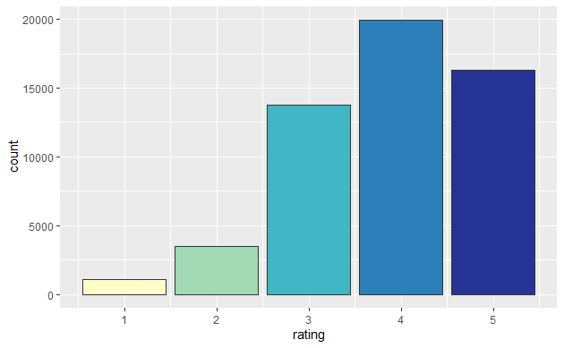

```r
ratings%>%
  ggplot(aes(x=rating,
             fill=factor(rating)))+
  geom_bar(color="grey20")+
  scale_fill_brewer(palette = "YlGnBu")+
  guides(fill= FALSE)
```

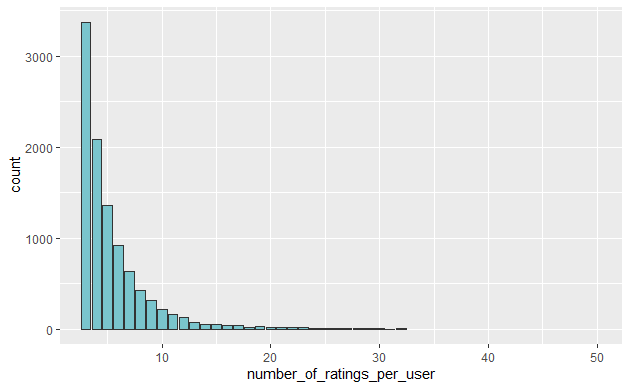

```r
ratings%>%
  group_by(user_id)%>%
  summarize(number_of_ratings_per_user = n())%>%
  ggplot(aes(number_of_ratings_per_user))+
  geom_bar(fill = "cadetBlue3",color = "grey20")+
  coord_cartesian(c(3,50))
```

###Numero de calificaciones por Usurios podemos observas que hay usuarios que han dado muchas calificaciones. Esto es interesante porque podemos examinar como se comportan las calificaciones de los usuarios mas activos a los menos activos.

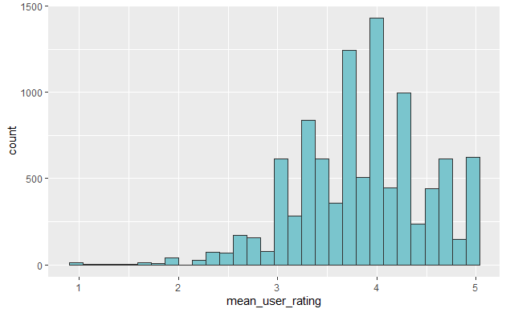

```r
ratings%>%
  group_by(user_id)%>%
  summarize(mean_user_rating=mean(rating))%>%
  ggplot(aes(mean_user_rating))+
  geom_histogram(fill="cadetblue3", color="grey20")
```

####Distribucion media de las calificaciones de los usuarios los usuarios tienen diferentes tendencias a calificar los libros. Algunos pueden dar 5 estrelllas a libros mediocres, mientras que otros no dan calificaciones de 5 a menos que sea un libro perfecto para ellos. Estas tendencias se pueden observar en la siguiente figuras. En el lado derecho hay un gran numero de usuarios con una calificacion media de 5, indicando que aquellos les gustaron todos los libros o solamente calificaron libros que le gustaron. tambien podemos observar que no hay calificaciones bajas. Estas tendencias seran importantes para el fitro colaborativo que veremos despues.

```
Ignoring unknown parameters: with
```

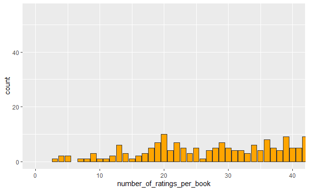

```r
ratings%>%
  group_by(book_id)%>%
  summarize(number_of_ratings_per_book = n())%>%
  ggplot(aes(number_of_ratings_per_book)) +
  geom_bar(fill = "orange", color = "grey20" , with = 1) + coord_cartesian(c(0,40))
```

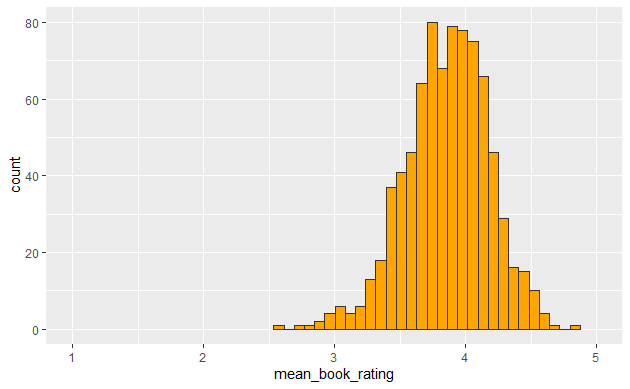

```r
ratings%>%
  group_by(book_id)%>%
  summarize(mean_book_rating = mean(rating))%>%
  ggplot(aes(mean_book_rating))+geom_histogram(fill = "orange", color="grey20") + coord_cartesian(c(1,5))
```

###Distribucion de la calificacion media de los libros la distribucion media no muestra ninguna pecularidad

```r
ratings%>%
  group_by(book_id)%>%
  summarize(mean_book_rating = mean(rating))%>%
  ggplot(aes(mean_book_rating))+geom_histogram(fill = "orange", color="grey20") + coord_cartesian(c(1,5))
```

[output not shown]